# Vibe coding and generative AI

Autonomy, sensitive data and sustainability in research settings

María Cristina Nanton

September 7, 2026

## About me

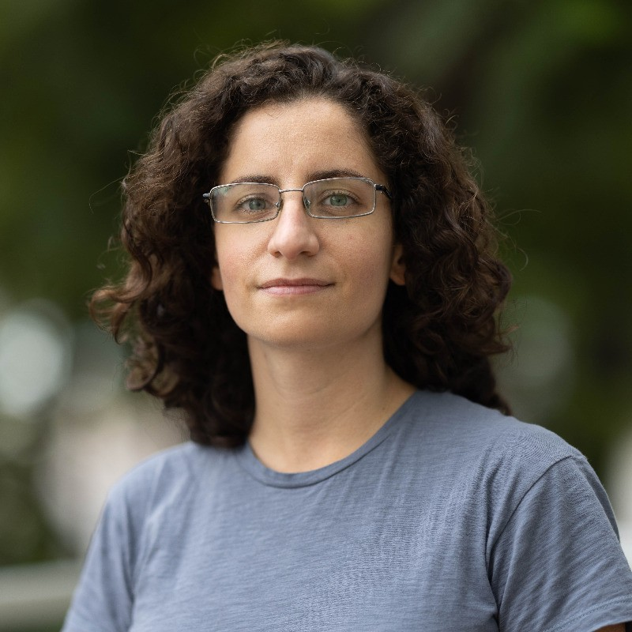

**María Cristina Nanton**

**Developer**  
Health Ministry @ Buenos Aires | The Global Health Network

Data science in the public sector  
Data-driven projects in a global health research network

mcnanton@gmail.com | [Linkedin](https://www.linkedin.com/in/mar%C3%ADa-cristina-n-920170126/) | [Web](https://mcnanton.github.io/)

# Vibe coding…

## … vibe coding?

There’s a new kind of coding I call “vibe coding”, where you fully give in to the vibes, embrace exponentials, and **forget that the code even exists**. It’s possible because the LLMs (e.g. Cursor Composer w Sonnet) are getting too good. […]

I ask for the dumbest things like “decrease the padding on the sidebar by half” because I’m too lazy to find it. I “Accept All” always, **I don’t read the diffs anymore**. When I get error messages I just copy paste them in with no comment, usually that fixes it. […]

I’m building a project or webapp, but it’s not really coding - I just see stuff, say stuff, run stuff, and copy paste stuff, and **it mostly works**.

— Andrej Karpathy, Twitter, February 2025 (emphasis mine)

# 1 - “We built something and it *works*”

## AI *within everyone’s reach*

Generative AI platforms that give access to advanced language models

**Claude** - Anthropic  
(Claude Opus 5, Sonnet 5, Fable 5.1)

**ChatGPT** - OpenAI  
(GPT-5.5 Instant, GPT-5.6 Sol)

**Copilot** - Microsoft  
(GPT-5.6, Claude Opus 5)

Conversational interface **+** specific ways to integrate them into code-based projects  
Claude Code | Codex | GitHub Copilot | Etc

## AI *within everyone’s reach*

And also **open models**: downloadable models you can run on your own infrastructure (a laptop, an institute server, an already-approved cloud)

**Who publishes them**

- **US**: Llama 4 (Meta) · Gemma 4 (Google) · gpt-oss (OpenAI)
- **Europe**: Mistral Small 4 (Mistral AI)
- **China**: Qwen 3.x (Alibaba) · DeepSeek V4 · GLM-5.1 (Z.ai) · Kimi K2 (Moonshot)

**What you need to run them**

- Small ones: a laptop
- Frontier ones: servers with several GPUs

**How they run**

- On your own computer or on a server

**What you gain**

- Privacy: the data doesn’t travel to a provider
- No changing terms of service
- Predictable cost: hardware, not tokens

If it runs on your own infrastructure, the data never leaves the institution.

## Platforms: describe the app and it appears (it even gets published!)

- A chat and a live preview: you describe what you want in plain language and the platform generates the **frontend** and, depending on the platform, also the **backend, database and login**, and publishes it in one click
- Nothing to install and nothing to *program*: the result is a usable product, accessible via a public URL
- Examples: **Lovable** | **Base44** | **Bolt.new** | **Replit** |**Claude (artifacts)** | ….

[figure not shown]

## What kind of products come out of this?

**Products such as**

- Institutional websites and landing pages
- Forms with validation and login
- Dashboards
- Prototypes to show a committee or funder

**Some examples I’ve seen**

- Digital publication prototype for an academic organization
- Student training site with a built-in LLM to answer questions
- Tool for managing students and research projects

## In short: autonomy and speed

- Prototypes in days or hours
- Faster iterations
- Fewer (or no) intermediaries

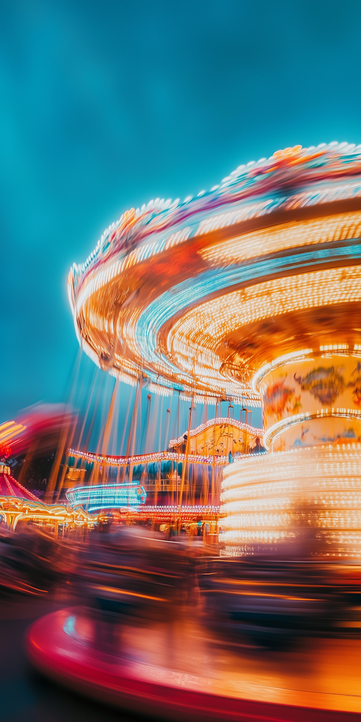

## Between prototype and production (1/2)

Some questions that often come up:

- How do I integrate this into my institution’s platform?
- How do I integrate specific tools: institutional login, scheduling, other platforms?
- How do I pay for it once I outgrow the free plan, or when the terms of service change?

[figure not shown]

## Between prototype and production (2/2)

- How do I know that the data my users enter (or that I entered) is secure?
- How hard would it be to build this from scratch in my organization?

[figure not shown]

# 2 - Making the most of autonomy without creating problems (for ourselves)

## Working with sensitive data

**The regulatory floor**

- By region: from very detailed frameworks to contexts with general regulation but no AI-specific guidance
- Institutional: it may or may not exist
- The absence of a rule that explicitly forbids something doesn’t make it safe or ethical

## Working with sensitive data

**Your own floor** — three questions before you start

- Could someone’s identity be reconstructed from the data I’m using?
- Who will access the data, and in what environment?
- Are there expectations about how the data will be handled?

Old problems, amplified: a Google Doc stays where you left it; a prompt can end up as training data, and an app generated with Lovable can publish its database to the internet.

## A recent example (1/2): AI credits for rare disease research

**Anthropic, AI for Science program** — thematic call (Jul 2026)

- Up to **USD 50,000 in Claude credits** for six months; applications open until August 2, 2026
- Two tracks: **basic science** and **early-stage biotechs** (starting doses, biomarkers, regulatory documentation)
- The rationale: ~400 million people living with one of more than 7,000 rare diseases; small populations, scattered data, shared mechanisms that are hard to detect

[figure not shown]

Source: anthropic.com/news/rare-disease-research-grants

## (2/2): “…need a safer framework for patient data”

**Julien Gagneur** (Technical University of Munich)

- The **terms are not fit for clinical or genomic patient data**: by accepting the credits, you guarantee that Anthropic may collect, analyze and **train models** on all inputs and outputs, under a **perpetual, irrevocable license**
- Having permission to *analyze* data is not the same as having permission to *transfer* it to a third party: the governance burden and legal risk shift to the researcher and their institution

## (2/2): “…need a safer framework for patient data”

- An agent connected to your local environment reads files, runs commands and sends outputs using your credentials: **data can leave without anyone uploading it**, especially if code is approved without being reviewed
- Proposal: a **protected research mode** — no training on or licensing of patient data, processing inside the approved environment, auditable controls and a clear data processing agreement. Open code, methods and evaluations

Source: [medium.com/@gagneur — “…need a safer framework for patient data”](https://medium.com/@gagneur/anthropics-ai-for-science-rare-disease-research-grants-need-a-safer-framework-for-patient-data-de319ce8f05b)

## Shadow AI: what are we talking about?

**Shadow AI** is the unsanctioned use of any artificial intelligence (AI) tool or application by employees or end users **without the formal approval or oversight of the information technology (IT) department.**

— [IBM, “What is shadow AI?”](https://www.ibm.com/think/topics/shadow-ai) (2024)

New risks: what data gets sent to commercial platforms and models, both voluntarily and involuntarily, and how a model’s outputs get absorbed into institutional assets.

## Shadow AI: the Samsung case (note: 2023)

- **2022**: ChatGPT launches
- **March 2023**: Samsung lifts an earlier restriction and allows ChatGPT
- **March–April 2023**: one engineer pastes the full source code of a program from their semiconductor database to ask for a fix; another does the same with code for faulty equipment; a third uploads an entire meeting to have it write up the minutes
- **Emergency measure**: a cap on prompt length
- **May**: the ban is back, now covering every generative AI tool. The reason, according to an internal memo: whatever is sent is stored on external servers, is hard to retrieve or delete, and could end up exposed to other users

Nobody meant to leak anything: each of them was solving a work problem with the tool at hand

Sources: [The Register, Apr 6, 2023](https://www.theregister.com/2023/04/06/samsung_reportedly_leaked_its_own) · [Gizmodo, Apr 2023](https://gizmodo.com/chatgpt-ai-samsung-employees-leak-data-1850307376) · [Bloomberg, May 2, 2023](https://www.bloomberg.com/news/articles/2023-05-02/samsung-bans-chatgpt-and-other-generative-ai-use-by-staff-after-leak)

## Why Shadow AI shows up in 2026

- Organizations without a dedicated IT team (or whose IT team has no capacity for groups interested in AI)
- No funding for institutional AI
- Lack of technical know-how to deploy AI within an institutional governance framework

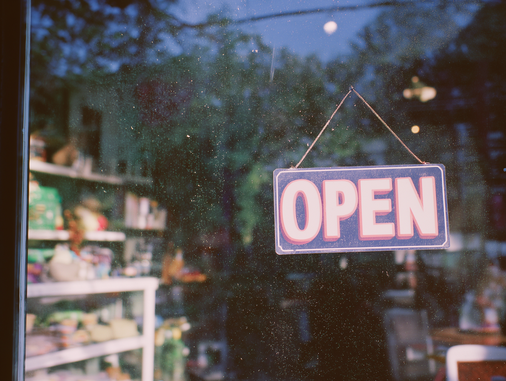

## Where data can leak

**What data?**

*Confidential*

- Credentials and keys: in a `.env` file, in the code, in a screenshot
- Databases and spreadsheets with personal data (patients, participants, staff)
- Medical records, results, samples

*Internal*

- Details about my projects or organization
- Internal code, protocols and documents

**Through where?**

- **The prompt**: “let me paste the table so you can help me”
- **The shared folder**: an AI with access to a folder reads everything in it
- **The terms of service**: the provider stores inputs and outputs and, depending on the plan, trains on them
- **What the AI generates**: apps with a public URL and a database with no access rules; repos with credentials inside
- **Integrations**: connectors to Drive, email or calendar; browser extensions

## Examples of university policies

[**Harvard**](https://www.huit.harvard.edu/ai/guidelines)

- Nothing confidential in public tools: research data, medical information, personnel records (not even for meeting minutes!)
- With default settings, whatever you share is not private
- Approved tools, licensed by the university, specifically for sensitive data

[**Penn State**](https://researchsupport.psu.edu/orp/education/generative-ai-in-research/)

- De-identification is not foolproof: AI can infer identities
- Metadata identifies too: file names, geolocation, dates
- Nothing identifiable without IRB approval
- Researchers must obtain participants’ consent if generative AI is used to analyze or process their data

[**Sheffield**](https://sheffield.ac.uk/rpi/pgr/guidance-pgrs-use-genai)

- Sensitive or proprietary data: commercial AI tools are prohibited
- [Self-guided risk and use assessment tool](https://shef.qualtrics.com/jfe/form/SV_djv3Eom5ZrQum6a)

## Minimum criteria before using AI with sensitive data (1/2)

1. **What kind of data is it?**  
   Classify it *before* opening the chat: public, internal or confidential
2. **With which tool?**  
   One approved by your institution, under a contract that prohibits training on your data
3. **Who authorized it?**  
   Patient or participant data → ethics committee + data agreement, before you start

## Minimum criteria before using AI with sensitive data (2/2)

4. **Can it be done with less?**  
   Anonymized or synthetic samples; no identifying metadata
5. **What else can the tool do?**  
   If it reads your data, consumes external content and can send things out → take away at least one of those
6. **Who reviews what comes out?**  
   Before publishing: who can read the database? Are any keys exposed?

Sources:  
[“Cuidado con lo que le confIAs” (in Spanish) — AEPD, 2026](https://www.aepd.es/prensa-y-comunicacion/notas-de-prensa/aepd-publica-decalogo-recomendaciones-proteger-privacidad-al-usar-ia)  
[“The lethal trifecta for AI agents” — S. Willison, 2025](https://simonwillison.net/2025/Jun/16/the-lethal-trifecta/)  
[“Common security risks in vibe-coded apps” — Wiz Research, 2025](https://www.wiz.io/blog/common-security-risks-in-vibe-coded-apps)

# Reflections and key questions

## If what you do with AI will have real impact

Any digital asset that affects people, projects or products in a research setting calls for assessing:

- Sustainability in the medium (or short!) term
- Security, sensitivity and institutional risk
- **Your own knowledge gaps about the problem you’re tackling with AI**

[figure not shown]

But also..

## Don’t be a “meat proxy”

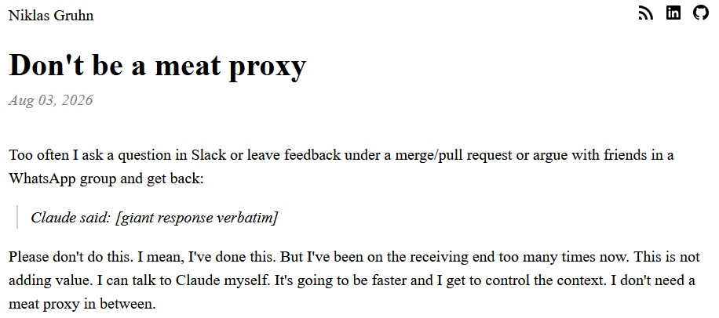

By all means, prompt AI. But don’t just relay the output. Read it, understand it, validate it, and then write a response in your own words (a decent certificate that you’ve done the prior steps). Making that effort is value you can add.

— Niklas Gruhn, “[Don’t be a meat proxy](https://gruhn.me/blog/2026-08-03/)”, August 3, 2026

On this, 3 key questions

What value are we expected to bring  
to the projects we work on?

What is worth investing time in?

Where data is stored is a decision

Is it your decision?

Thank you!

**María Cristina Nanton**  
mcnanton@gmail.com